# Ordinal Analysis Final (w/o CIs)

Author

Simmons & Girard

Published

May 20, 2026

# 1. Setup

```r
library(tidyverse)
library(simhelpers)
library(gt)
library(paletteer)
library(ggpubr)
library(gtExtras)
```

{gt} styling template

```r
#{gt} Theme --
my_gt_theme <- function(gt_object){
  gt_object |>
  opt_table_font(
    font = list(
      google_font(name = "Arial"), # Preferred
      "serif")) |>
  tab_options(
    table.border.top.style = "none",
    table.border.bottom.style = "solid",
    table.border.bottom.width = px(2),
    column_labels.border.top.style = "solid",
    column_labels.border.top.width = px(2),
    column_labels.border.bottom.style = "solid",
    column_labels.border.bottom.width = px(1),
    table_body.border.bottom.style = "solid",
    table_body.border.bottom.width = px(2)
  )
}
# ----
```

Helper Functions

```r
# read in nested data
nest_rds_files <- function(data_df, filename_col, directory_path) {
  # 1. Ensure the directory path ends with a slash for file path construction
  dir <- ifelse(grepl("/$", directory_path), directory_path, paste0(directory_path, "/"))

  # 2. Create the new nested column
  # We use sym() to handle the column name if passed as a string
  result_df <- data_df %>%
    mutate(result = map(!!sym(filename_col), function(fname) {
      file_path <- paste0(dir, fname)

      # Check if file exists to avoid crashing the whole loop
      if (file.exists(file_path)) {
        return(readRDS(file_path))
      } else {
        warning(paste("File not found:", file_path))
        return(NULL)
      }
    }))

  return(result_df)
}
```

Plot functions

```r
# plot boxplots with MCSEs
plot_revised_boxplots <- function(data, x_factor) {

   clean_label <- function(var_name) {
    case_when(
      var_name == "n_raters"   ~ "Number of Raters",
      var_name == "n_objects"  ~ "Number of Objects",
      var_name == "target_icc" ~ "Target ICC Value",
      var_name == "k_category" ~ "Number of Categories (K)",
      var_name == "e_category" ~ "Equality of Categories",
      var_name == "bias2"      ~ "Percent Bias",
      TRUE                     ~ var_name
    )
   }

   # add monte carlo standard error layer
  mcse_bounds <- data |>
    group_by(.data[[x_factor]], Method, icc) |>
    summarize(
      mid_point = median(bias2),
      avg_mcse = sqrt(mean(bias2_mcse^2)),
      .groups = "drop")

  fixed_dodge <- position_dodge(width = 0.75)

  # FIX: Use .data[[x_factor]] to process the incoming string name safely
   #layer the MCSE bars first
  ggplot(data) +
    # Layer 1: Background MCSE Bars (Shows the execution/sampling noise layer)
  geom_linerange(
      data = mcse_bounds,
      aes(
        x = factor(.data[[x_factor]]),
        ymin = mid_point - avg_mcse,
        ymax = mid_point + avg_mcse,
        group = Method
      ),
      color = "purple", linewidth = 4, position = fixed_dodge,
      alpha = 1) +
  geom_boxplot(aes(x = factor(.data[[x_factor]]),
  y = bias2, fill = Method),
  outliers = TRUE, outlier.size = 0.5,
  alpha = 0.7, outlier.shape = NA,
  position = fixed_dodge
  ) +
  facet_wrap(vars(icc), labeller = label_both) +
    labs(
      #title = "Bias Analysis (Ordinal)",
      # Dynamically evaluate the clean label based on the specific loop iteration
      x = clean_label(x_factor),
      y = clean_label("bias2"),
      fill = "Method"
    ) +
    theme_bw() +
    theme(legend.position = "bottom") +
    geom_hline(yintercept = 0, color = "lemonchiffon4", linetype = "dashed", linewidth = 0.5) +
    geom_hline(yintercept = -0.10, color = "red", linetype = "dashed") +
    geom_hline(yintercept = 0.10, color = "red", linetype = "dashed") +
    annotate(
    "label",
    x = Inf, y = Inf, # Places it precisely in the top-right corner
    label = paste0("Max % MCSE: ", round(max(mcse_bounds$avg_mcse, na.rm = TRUE), 5)),
    vjust = 1.5, hjust = 1.1,
    fill = "white", alpha = 0.8, size = 3, fontface = "italic"
  )
}

plot_multi_facet_correlation <- function(data,
                                        # col_factor,
                                        caa_metric = "kappa_adj",
                                        icc_metric = "g_icc"
                                         ) {

  # Clean labels for the columns and rows
  get_label <- function(x) {
    case_when(
      x == "n_raters"   ~ "Number of Raters",
      x == "n_objects"  ~ "Number of Objects",
      x == "target_icc" ~ "Target ICC Value",
      x == "k_category" ~ "Number of Categories (K)",
      x == "icc_type"   ~ "ICC Metric Type",
      x == "kappa_adj" ~ "Kappa Adjusted",
      x == "s_bp_adj"  ~ "Brennen-Prediger Adjusted",
      x == "g_icc" ~ "G-ICC",
      TRUE              ~ x
    )
  }

  # Join CCAs and ICCs (Ensures Kappa and ICC are paired correctly)
  caa_df <- data %>%
    filter(method == caa_metric) %>%
    rename(baseline_val = mean_estimate) %>%
    select(-method)

  icc_df <- data %>%
    filter(method != caa_metric) %>% # Assumes other metrics are your ICCs
    filter(method == icc_metric) %>%
    rename(icc_val = mean_estimate) %>%
    select(-method,icc)

  cor_data <- inner_join(caa_df, icc_df,
                         by = c("n_raters", "n_objects", "target_icc", "k_category","e_category", "icc_type","condition"))
                         #%>%

  # Plotting with Dynamic Faceting
  ggplot(cor_data, aes(x = baseline_val, y = icc_val, color = icc_type)) +
    geom_point(alpha = 0.3, size = 1) +
    geom_smooth(method = "lm", se = FALSE, linewidth = 0.8) +
    stat_cor(aes(label = ..r.label..), method = "pearson", size = 3) +
    labs(
      title = paste("Correlation Analysis:", get_label(caa_metric), "vs", get_label(icc_metric)),
      # subtitle = paste("Faceted by", get_label(row_factor), "and", get_label(col_factor)),
      subtitle = paste("Faceted by ICC Data Generating Process"),
      x = paste("Average", get_label(caa_metric)),
      y = "Average G-ICC Estimate",
      color = "ICC-DGP Type"
    ) +
    theme_bw() +
    theme(legend.position = "bottom") +
    geom_abline(intercept = 0, slope = 1, color = "orange", linetype = "dashed")
}
```

# Load Data

```r
DIR <-  "~/Documents/Github/MastersThesis/iccs/data/universe_4/"
```

```r
# Paramter Grid
design_factors <- list(
n_raters = c(3,12,24),
n_objects = c(10,50,100),
target_icc = c(0.40,0.60,0.80),
k_category = c(3,5,7),
e_category = c(TRUE,FALSE),
# 1 = equal category prevalence, #0 = unequal linear decay prevalence
icc_type = c(1,2,3,4)
)
# Expand grid and
# Join each data file to its condition
params <- expand_grid( !!!design_factors) |>
    mutate(
    seed = 03122026 + 17 * 1:n(), #set seed for each row,
    condition = 1:n() * 1,
    filename = paste0("ordinal_Ufour_",condition,"_",seed,".rds"))

dat_nest <- nest_rds_files(params, "filename", DIR)
# params2 <- params |>
#   select(-filename) |>
#   mutate(filename = paste0(
#     "ordinal_onlyglmmtmb_",condition,"_",seed,".rds"))

# #glmmtmb linear fits only
# dat_nest2 <- nest_rds_files(params2, "filename", DIR)

# dat_nest3 <- readRDS("~/Documents/Github/MastersThesis/iccs/data/fullsets/ordinal_Uthree5_AOV.rds")
```

# 2. Data Wrangling (Part 1)

Here, I unnested the entire simulation sets to obtain the full data

```r
dat <- dat_nest |> unnest(result)
# dat2 <- dat_nest2 |> unnest(result) #only linear *not generalized* glmmsTMB fits
# dat3 <- dat_nest3 |> unnest(result) #only fixed AOV fits (J.G. fix)

# Delete nested object
rm(dat_nest) # no longer neaded
# rm(dat_nest2) #no longer needed
# rm(dat_nest3) #no longer needed
```

Need to replace the AOV fits in `dat` with `dat3` (thanks to J.G. Fix)

```r
# dat <- dat |>
#   filter(method != "aov_icc") |>
#   bind_rows(dat3) #dat3 only contains fixed "aov_icc"

# rm(dat3) # no longer needed
```

Critically, datasets were subsetted so that each g_icc() is matched with its corresponding data generating variance (DGP) hyper-parameters

```r
# for point-estimate analyses, combine first with dat2
#dat_full <- bind_rows(dat, dat2) |>
dat_full <- dat |>
  select(-seed, -filename) |>
  filter(
    (icc_type == 1 & icc == "ICC(A,1)") |
    (icc_type == 2 & icc == "ICC(A,k)") |
    (icc_type == 3 & icc == "ICC(C,1)") |
    (icc_type == 4 & icc == "ICC(C,k)"))


# for CAA analysis
#dat_caa <- bind_rows(dat,dat2) |>
dat_caa <- dat |>
  select(-seed, -filename) |>
  filter(is.na(icc)) |> #select only caa measures
  bind_rows(dat_full) # match ICCs with correct DGP

# Clean up
rm(dat)
```

# 3. TROUBLESHOOTING ICC FORMULATIONS

Troubleshooting ICC Formulations: CONTEXT

- Since J.G. and I already confirmed that using `signif()` is not an advisible thing to do, we will not test this
- Since all the ICC estimates from analyses prior to today, May 19, when we found out this issue use `signif()` it is clear that we need to recalculate ICCs from the original model variances. In other words, there is no reason to compare ICC calculated from previous analyses that utilized `signif()` to future ICCs we calculate post-simulations.

Troubleshooting ICC Formulations: THE PLAN

We will test the following conditions:

- 1. ICCs from equations using round() and with excessive parenthesis
- 2. ICCs from equations without round() and with excessive parenthesis
- 3. ICCs from equations using round() and with less parenthesis ({varde} style)
- 4. ICCs from equations without round() and with less parenthesis ({varde} style)

Each condition will be represented respectively by the following functions.

- Note: `icc_type` is passed into each of these test functions.
- `icc_type` was the value passed to the data-generating functions at the beginning of simulations to produce the variance parameters. It is the “ground-truth” code for all models’ variances.

## Function `#1` -> Test Condition `#1`

The following function “calc_icc_test1()” takes a value (`icc_type`).

```r
calc_icc_test1 <- function(icc_type_dgp, vs, vr, vsr, k) {
  # goal is to create post-hoc ICC values given the original `icc_type` values in the data-generating process.

  icc_type_dgp <- as.character(icc_type_dgp)
  # Uses ROUND and Excessive Parenthesis
  round(
   case_when(
    icc_type_dgp == "1" ~ vs / (vs + vr + vsr),
    icc_type_dgp == "2" ~ (vs) / (vs + ((vr+vsr)/k)),
    icc_type_dgp == "3" ~ vs / (vs + vsr),
    icc_type_dgp == "4" ~ (vs) / (vs + (vsr/k)),
    TRUE                       ~ NA_real_
  ),
  digits = 3)

}
```

## Function `#2` -> Test Condition `#2`

```r
calc_icc_test2 <- function(icc_type_dgp, vs, vr, vsr, k) {
  # DO NOT ROUND, but USE EXCESSIVE PARENTHESES

  icc_type_dgp <- as.character(icc_type_dgp)


   case_when(
    icc_type_dgp == "1" ~ vs / (vs + vr + vsr),
    icc_type_dgp == "2" ~ (vs) / (vs + ((vr+vsr)/k)),
    icc_type_dgp == "3" ~ vs / (vs + vsr),
    icc_type_dgp == "4" ~ (vs) / (vs + (vsr/k)),
    TRUE                       ~ NA_real_
  )

}
```

## Function `#3` -> Test Condition `#3`

```r
calc_icc_test3 <- function(icc_type_dgp, vs, vr, vsr, k) {
  # ROUND, and use less PARENTHESES
  # Parentheses is equivalent to the original {varde} icc formulations
  icc_type_dgp <- as.character(icc_type_dgp)

  round(
    case_when(
      icc_type_dgp == "1" ~ vs / (vs + vr + vsr),
      icc_type_dgp == "2" ~ vs / (vs + (vr + vsr) / k),
      icc_type_dgp == "3" ~ vs / (vs + vsr),
      icc_type_dgp == "4" ~  vs / (vs + vsr / k),
      TRUE                       ~ NA_real_),
  digits = 3)
}
```

## ## Function `#4` -> Test Condition `#4`

```r
calc_icc_test4 <- function(icc_type_dgp, vs, vr, vsr, k) {
  # DO NOT ROUND, and use less PARENTHESES
  # Parentheses is equivalent to the original {varde} icc formulations

  icc_type_dgp <- as.character(icc_type_dgp)

  case_when(
    icc_type_dgp == "1" ~ vs / (vs + vr + vsr),
    icc_type_dgp == "2" ~ vs / (vs + (vr + vsr) / k),
    icc_type_dgp == "3" ~ vs / (vs + vsr),
    icc_type_dgp == "4" ~  vs / (vs + vsr / k),
    TRUE                       ~ NA_real_
  )
}
```

## Using test functions on real data manually

`dat_full` contains the variances from ANOVA, linear mixed models, gerneralized linear-mixed models for all simulation conditions

Example Variances from row 1 of `dat_full`

```r
test_example_row1 <- list(
  icc_type_dgp = dat_full$icc_type[[1]],
  vs = dat_full$vs[[1]], #vs = object variance
  vr = dat_full$vr[[1]], #vr = rater variance
  vsr = dat_full$vsr[[1]], #vsr = error variance
  k = dat_full$n_raters[[1]] #n_rater
 )

do.call(calc_icc_test1,test_example_row1) #round(), excessive parenthses
```

```
[1] 0.336
```

```r
do.call(calc_icc_test2,test_example_row1) #no round(), excessive parenthses
```

```
[1] 0.3360663
```

```r
do.call(calc_icc_test3,test_example_row1) #round(), less parentheses
```

```
[1] 0.336
```

```r
do.call(calc_icc_test4,test_example_row1) #no round(), less parentheses
```

```
[1] 0.3360663
```

Example Variances from row 27 (I chose random number) of `dat_full`

```r
test_example_row1 <- list(
  icc_type_dgp = dat_full$icc_type[[27]],
  vs = dat_full$vs[[27]], #vs = object variance
  vr = dat_full$vr[[27]], #vr = rater variance
  vsr = dat_full$vsr[[27]], #vsr = error variance
  k = dat_full$n_raters[[27]] #n_rater
 )

do.call(calc_icc_test1,test_example_row1) #round(), excessive parenthses
```

```
[1] 0.086
```

```r
do.call(calc_icc_test2,test_example_row1) #no round(), excessive parenthses
```

```
[1] 0.0859375
```

```r
do.call(calc_icc_test3,test_example_row1) #round(), less parentheses
```

```
[1] 0.086
```

```r
do.call(calc_icc_test4,test_example_row1) #no round(), less parentheses
```

```
[1] 0.0859375
```

## TROUBLESHOOTING RESULT: USE either test function #2 or #4

Conclusion: It is best to NOT round and excessive parenthesis do not matter

As a separate test, let’s compare how different the calulcation of ICCs using signif (created in simulation code), and newly fixed ICCs using the correct ICC troubleshooting function:

```r
# found errors in the simulation math!?

dat_full2 <- dat_full |>
  mutate(
    # This creates a brand new column with the correct math applied row-by-row
    sim_icc = estimate, #copy next easily compare next to fixed_estimates
    fixed_estimate = calc_icc_test4(icc_type, vs, vr, vsr, n_raters),
  )


mismatches <- dat_full2 |>
  filter(sim_icc != fixed_estimate)

mismatches
```

```
# A tibble: 545,568 × 23
   n_raters n_objects target_icc k_category e_category icc_type condition method
      <dbl>     <dbl>      <dbl>      <dbl> <lgl>         <dbl>     <dbl> <chr>
 1        3        10        0.4          3 TRUE              1         1 aov_i…
 2        3        10        0.4          3 TRUE              1         1 aov_i…
 3        3        10        0.4          3 TRUE              1         1 aov_i…
 4        3        10        0.4          3 TRUE              1         1 aov_i…
 5        3        10        0.4          3 TRUE              1         1 aov_i…
 6        3        10        0.4          3 TRUE              1         1 aov_i…
 7        3        10        0.4          3 TRUE              1         1 aov_i…
 8        3        10        0.4          3 TRUE              1         1 aov_i…
 9        3        10        0.4          3 TRUE              1         1 aov_i…
10        3        10        0.4          3 TRUE              1         1 aov_i…
# ℹ 545,558 more rows
# ℹ 15 more variables: icc <chr>, estimate <dbl>, ci_lower <dbl>,
#   ci_upper <dbl>, sigma_s <dbl>, sigma_r <dbl>, sigma_vsr <dbl>, vs <dbl>,
#   vr <dbl>, vsr <dbl>, message <chr>, warning <chr>, error <chr>,
#   sim_icc <dbl>, fixed_estimate <dbl>
```

# 4. Data Wrangling (Part 2)

Replace simulation icc estimates with corrected icc estimates (see troubleshooting above), and set factors

```r
# #clean up
rm(dat_full2)
rm(mismatches)

# fix ICCs
dat_full <- dat_full |>
  mutate(estimate = calc_icc_test4(icc_type, vs, vr, vsr, n_raters))


#set conditions as factors
conds <- c("n_raters", "n_objects", "k_category", "e_category", "icc_type", "condition", "method","icc")
dat_full <- dat_full |>
  mutate(across(.cols = all_of(conds), .fns = as.factor))
```

# 5. Descriptives Analyses

## Simulation Error Rates

First, let’s check how many conditions obtained errors. Here, I considered a simulation to *fail* whenever there was a “message”, “warning”, or “error” associated with any one model fit in {lm} for ANOVA, and {lme4}, {glmmTMB}, and {ordinal} for LMMs.

Here: Errors are conditional on ICC type and method

```r
errors <- dat_full |>
  mutate(
    across(.cols = c("message","warning","error"), .fns = as.logical)) |>
  mutate( is_invalid = message | warning | error) |>
  summarise(
    total_trials = n(),
    invalid_trials = sum(is_invalid, na.rm = TRUE),
    percent_error = mean(is_invalid, na.rm = TRUE) * 100,
    .by = c(method,icc)
  ) |>
  arrange(match(method, c("icc","icc_glmmtmb", "g_icc","aov_icc"))
  ) |>
  arrange(icc) |>
  mutate(method = fct_recode(method,
 # "LMM {lme4}" = "icc",
  "LMM {glmmtmb}" = "icc",
  "GLMM {ordinal}" = "g_icc",
  "ANOVA {stats}" = "aov_icc",
  ))
```

## Negative ICC rates

Negative ICCs conditional on ICC type and method

```r
negative_summary <- dat_full |>
  summarise(
    total_trials = n(),
    negative_count = sum(estimate < 0, na.rm = TRUE),
    .by = c(method,icc),
    negative_pct = mean(estimate < 0, na.rm = TRUE)
  ) |>
  arrange(match(method, c("icc","icc_glmmtmb", "g_icc","aov_icc"))
  ) |>
  arrange(icc) |>
  mutate(method = fct_recode(method,
  #"LMM {lme4}" = "icc",
  "LMM {glmmtmb}" = "icc",
  "GLMM {ordinal}" = "g_icc",
  "ANOVA {stats}" = "aov_icc",
  ))
```

## Descriptive Results Tables (Goes in Thesis)

```r
dplot <- left_join(errors, negative_summary) |>
  gt() |>
  my_gt_theme() |>
  #apa guidlines say do the titles in word
  # tab_header(
  #   title = "Simulation Failure and Negative ICC Rates (Ordinal Data)",
  #   subtitle = "Comparing Across Method and ICC Type"
  # ) |>
  # Format the percentage column (adds the % sign and rounds to 1 decimal)
  fmt_percent(
    columns = c(percent_error, negative_pct),
    scale_values = FALSE,
    decimals = 2
  ) |>
  # Make the column names look professional
  cols_label(
    method = "Method",
    icc = "ICC Type",
    total_trials = "Total (N)",
    invalid_trials = "Non-Convergence (N)",
    percent_error = " % Non-Convergence",
    negative_count = "Negative ICC (N)",
    negative_pct = "% Negative"
  ) |>
  data_color(
    column = icc,
    target_columns = everything(),
    method = "factor",
    palette = "RColorBrewer::Greys"
  ) |>
  tab_style(
    style = cell_borders(
      sides = c("left","right"),
      color = "black",
      weight = px(1),
      style = "solid"
    ),
    locations = cells_body(columns = c("percent_error", "negative_pct"))
    ) #|>
    #   gtsave("all_descriptives_ordinal_full.png")

dplot
```

| Method | ICC Type | Total (N) | Non-Convergence (N) | % Non-Convergence | Negative ICC (N) | % Negative |
| --- | --- | --- | --- | --- | --- | --- |
| LMM {glmmtmb} | ICC(A,1) | 159000 | 49 | 0.03% | 0 | 0.00% |
| GLMM {ordinal} | ICC(A,1) | 159000 | 552 | 0.35% | 0 | 0.00% |
| ANOVA {stats} | ICC(A,1) | 159000 | 0 | 0.00% | 417 | 0.00% |
| LMM {glmmtmb} | ICC(A,k) | 159000 | 434 | 0.27% | 0 | 0.00% |
| GLMM {ordinal} | ICC(A,k) | 159000 | 1 | 0.00% | 0 | 0.00% |
| ANOVA {stats} | ICC(A,k) | 159000 | 0 | 0.00% | 6808 | 0.04% |
| LMM {glmmtmb} | ICC(C,1) | 159000 | 49 | 0.03% | 0 | 0.00% |
| GLMM {ordinal} | ICC(C,1) | 159000 | 26 | 0.02% | 0 | 0.00% |
| ANOVA {stats} | ICC(C,1) | 159000 | 0 | 0.00% | 502 | 0.00% |
| LMM {glmmtmb} | ICC(C,k) | 160000 | 437 | 0.27% | 0 | 0.00% |
| GLMM {ordinal} | ICC(C,k) | 160000 | 1 | 0.00% | 0 | 0.00% |
| ANOVA {stats} | ICC(C,k) | 160000 | 0 | 0.00% | 6946 | 0.04% |

# 6. Point-Estimate Bias Analyses + Boxplots

Calculate Bias, RMSE and their Monte Carlo Standard Errors (MCSEs)

- Note: Percent Bias, MCSEs are NOT rounded

```r
bias <- dat_full |>
  # some NA (4) in g-ICC(C,k) and negative aov_iccs
  # filter(estimate >= 0 )|>
 # filter(method != "icc") |> # Makes it easier to assess LMM-ICCs since so similar
  summarize(
    simhelpers::calc_absolute(
      estimates = estimate, true_param = target_icc,
      criteria = c("bias","stddev","rmse")
    ),
    .by = c(n_raters, n_objects, target_icc, icc, k_category, e_category, icc_type, condition, method)
  ) |>
  mutate(bias2 = bias/target_icc) |> #Muthen&Muthen
  mutate(bias2_mcse = bias_mcse/target_icc) |> #Muthen&Muthen
  mutate(Method = fct_recode(method,
   # "LMM {lme4}" = "icc",
    "LMM {glmmtmb}" = "icc",
    "GLMM {ordinal}" = "g_icc",
    "ANOVA {lm}" = "aov_icc", )
  ) |>
  mutate(Objects = n_objects) |>
  mutate(`Target ICC` = target_icc) |>
  mutate(`Category Equality` = e_category)
```

Plot Percent Bias Boxplots to go in Thesis

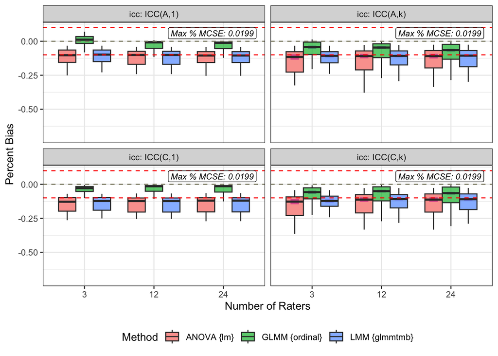

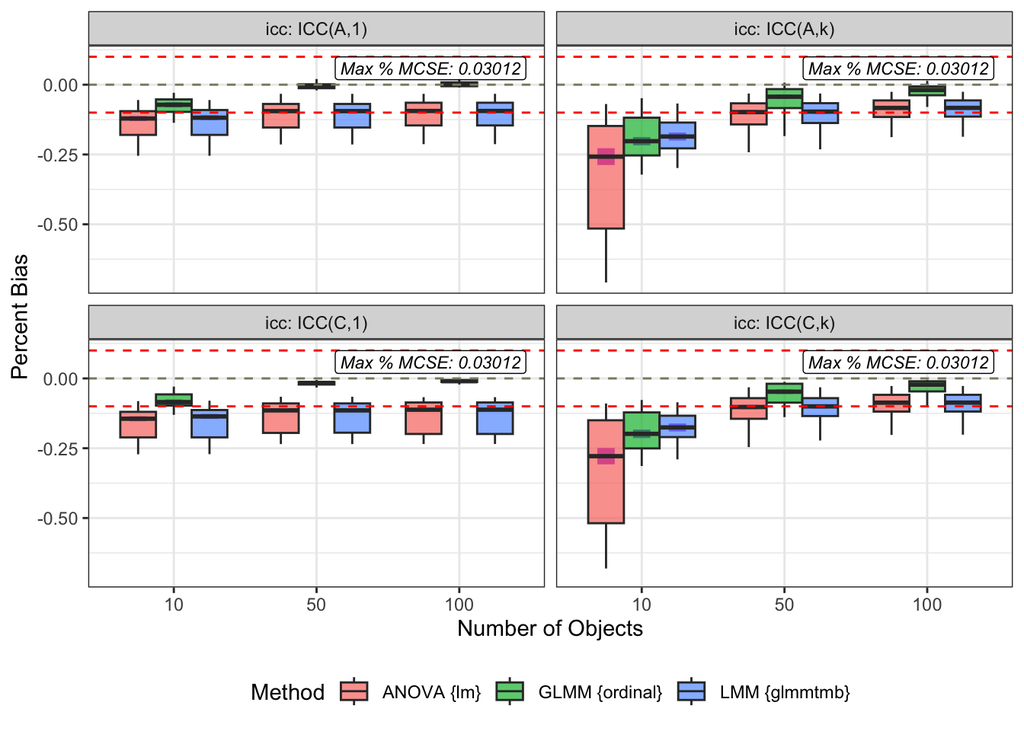

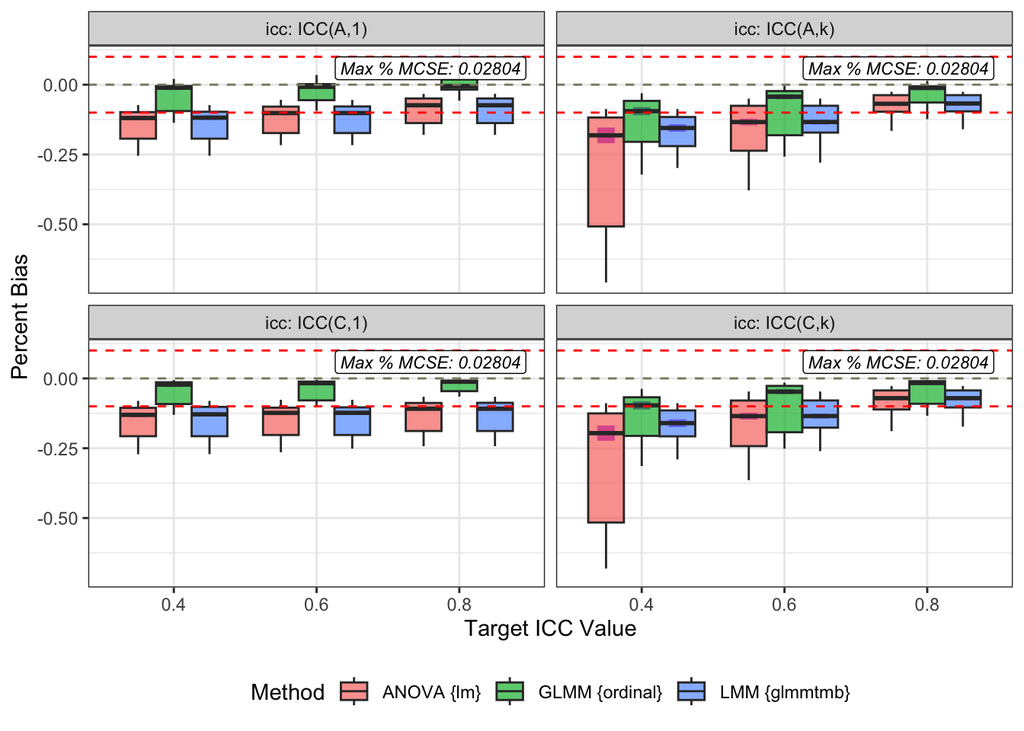

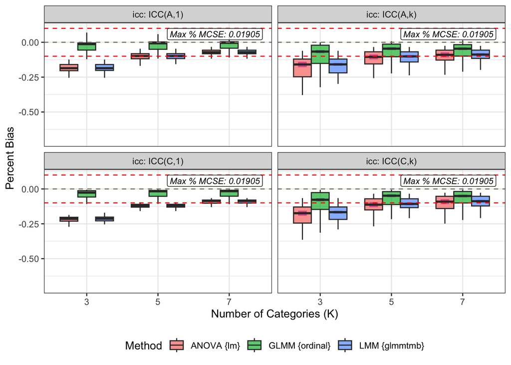

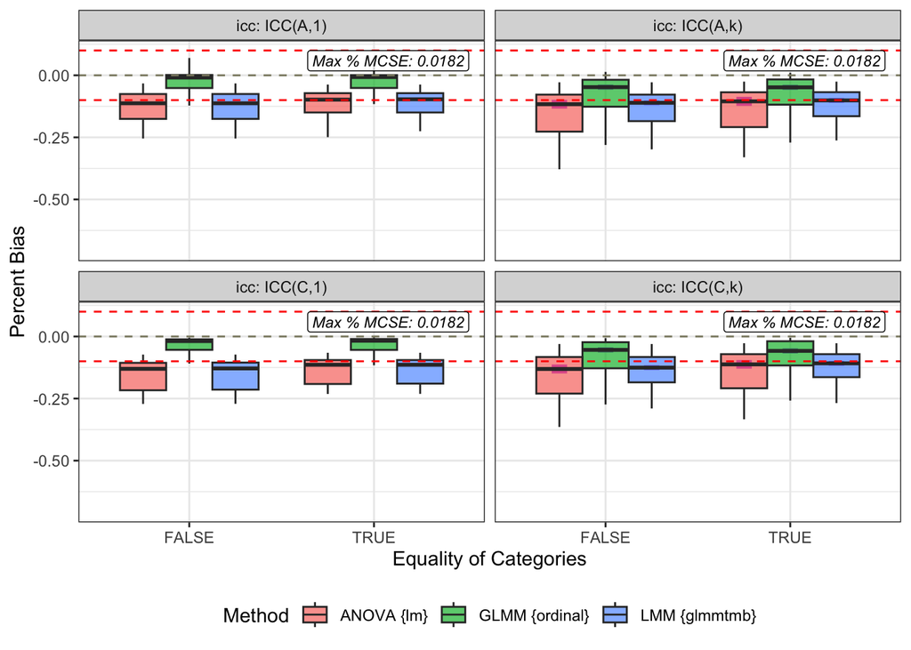

```r
factors_to_test <- c("n_raters", "n_objects", "target_icc", "k_category", "e_category")

# FIX: Added '~' before the function call so R evaluates '.x' loop by loop
mm_boxplots <- map(set_names(factors_to_test), ~ {
  plot_revised_boxplots(
    data = bias,
    x_factor = .x
  )
})

mm_boxplots
```

# 7. Comparision to CAAs (Correlation Tables)

## Comparison to CAA

Create ICC & CAA averages across simulation conditions

```r
dat_avg <- dat_caa |>
  #filter(method != "icc") |> # Makes it easier to assess LMM since so similar
  summarize(
    mean_estimate = mean(estimate),
    .by = c(n_raters, n_objects, target_icc, icc, k_category, e_category, icc_type, condition, method)
  ) |>
  mutate(
    # Convert double to factor /  Rename the levels
    icc_type = as.factor(icc_type),
    icc_type = fct_recode(icc_type,
      "ICC(A,1)" = "1",
      "ICC(A,k)"  = "2",
      "ICC(C,1)" = "3",
      "ICC(C,k)" ="4"
    )
  )
rm(dat_caa) # save RAM space
```

Create correlation plots to put into thesis

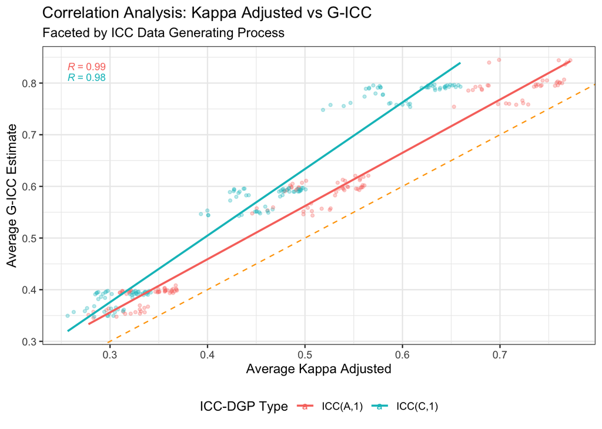

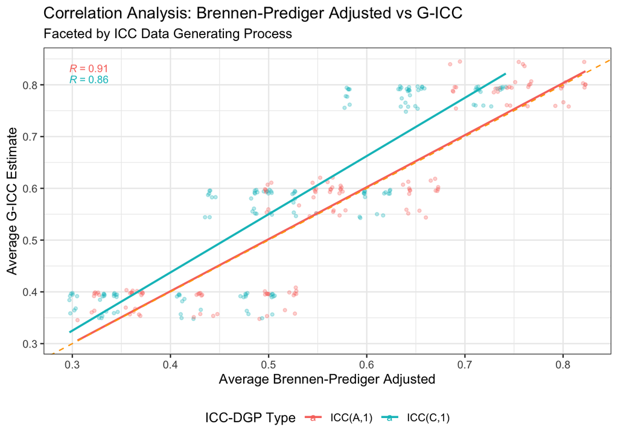

```r
# Define the factors you want to loop through
factors_to_analyze <- c("kappa_adj", "s_bp_adj")

# only include a1 and c1

dat_a1c1 <- dat_avg |>
  filter(icc_type == "ICC(A,1)" | icc_type == "ICC(C,1)")

# Generate the plots
cor_plots <- map(set_names(factors_to_analyze), ~ {
  plot_multi_facet_correlation(
    data = dat_a1c1,
    caa_metric = .x,
  )
})

cor_plots
```

```r
# Save
# output_dir <- "icc_kappa_correlations"
# if (!dir.exists(output_dir)) dir.create(output_dir)

# iwalk(hyper_cor_plots, function(p, factor_name) {
#   ggsave(
#     file.path(output_dir, paste0("hyper_corr_", factor_name, ".png")),
#     plot = p, width = 16, height = 12, dpi = 300
#   )
# })
```